# PSY 8712 Week 8 Project

Mackenzie R Nickle

2024-03-16

# **Reproducible Image and Online Resources**

An image of this project as of *March 15, 2024* can be accessed by clicking [my_binder_shiny_week8](https://mybinder.org/v2/gh/nickl103/psy8712_week8/HEAD).

An interactive web app is available by clicking [Shiny_Week8](https://nickl103.shinyapps.io/shiny_week8/) instead.

# **Script Settings and Resources**

```r
setwd(dirname(rstudioapi::getActiveDocumentContext()$path))
library(tidyverse)
library(shiny)
library(rsconnect)
```

# **Data Import and Cleaning**

```r
week8_tbl <- read_csv("../data/week3.csv") %>%
  mutate(timestart= ymd_hms(timeStart),
         q5= 6-q5,
         across(starts_with("q"), as.numeric),
         condition= factor(condition,
                           levels=c("A","B","C"),
                           labels= c("Block A","Block B","Control")),
         gender= factor(gender,
                        levels=c("M","F"),
                        labels= c("Male","Female"))) %>%
  mutate(avg_q1q6= rowMeans(select(., q1:q6)),
         avg_q8q10= rowMeans(select(., q8:q10)))
```

# **Visualization**

Updated YAML header to include paged so the data would show up in page format on the html file as requested. I used paste0 for selecting columns so that it could easily be changed to a different selection of columns. For data visualization, I used ggplot to create a scatterplot to include various customization options such as geom_smooth and labels.

| q1 | q2 | q3 | q4 | q5 | q6 |
| --- | --- | --- | --- | --- | --- |
| 5 | 4 | 4 | 1 | 2 | 1 |
| 2 | 4 | 3 | 1 | 3 | 1 |
| 5 | 5 | 2 | 1 | 5 | 1 |
| 4 | 3 | 4 | 2 | 4 | 1 |
| 3 | 1 | 3 | 5 | 2 | 1 |
| 4 | 3 | 2 | 3 | 3 | 1 |
| 2 | 4 | 1 | 3 | 1 | 1 |
| 4 | 2 | 5 | 1 | 1 | 1 |
| 2 | 5 | 3 | 4 | 2 | 1 |
| 3 | 4 | 2 | 4 | 5 | 1 |

[output cut: 39 more lines]

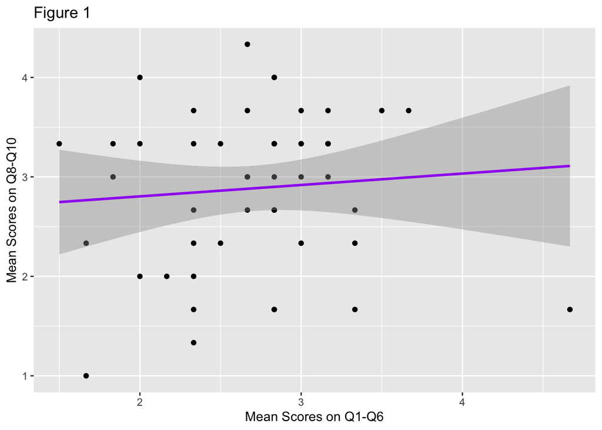

# **Analysis**

```
##
##  Pearson's product-moment correlation
##
## data:  week8_tbl$avg_q1q6 and week8_tbl$avg_q8q10
## t = 0.58309, df = 47, p-value = 0.5626
## alternative hypothesis: true correlation is not equal to 0
## 95 percent confidence interval:
##  -0.2012466  0.3574248
## sample estimates:
##        cor
## 0.08474575
```

Based on the correlation test, the correlation between the mean scores for questions 1-6 and for the mean scores for questions 8-10 is .08. The p-value was not significant at .56 because it is greater than .05. To format the correlation, I used format() from the class slides.

# **Data Export**

I used saveRDS for data export as recommended in the class slides. I dropped timeStart, the specific q numbers, and condition as they were not needed for anything for the shiny app.

```r
week8_tbl %>%
  select(timeEnd, gender, avg_q1q6, avg_q8q10) %>%
  saveRDS("../shiny/shiny_week8/w8.rds")
```